# MATH-23C PROJECT - Analysis of /r/ForeverAlone Dataset

# Depression and Suicide

Is depression and suicide correlated?

## Depression and Suicide: using Contingency table to find correlation

```r
observed <- table(ForeverAlone$depressed, ForeverAlone$attempt_suicide); observed
  #      No Yes
  # No  147  10
  # Yes 237  75
```

It’s no surprise to me that those who are depressed are more likely to attempt suicide. Now let’s try to compare with an expected contingency table.

```r
pDepressed <- mean(ForeverAlone$depressed == 'Yes')
pAttempted <- mean(ForeverAlone$attempt_suicide == 'Yes')
expected <- nrow(ForeverAlone) * outer(c(1 - pDepressed, pDepressed), c(1 - pAttempted, pAttempted)); expected
#          [,1]     [,2]
# [1,] 128.5458 28.45416
# [2,] 255.4542 56.54584
#
# looks pretty close from observed!

chisq <- sum((observed-expected)^2/expected); chisq # 21.97367
pValue <- 1 - pchisq(chisq, 1); pValue # 2.764167e-06
# Using the built in chisq method...
chisq.test(ForeverAlone$depressed, ForeverAlone$attempt_suicide, correct=FALSE)
#
#   Pearson's Chi-squared test
#
# data:  ForeverAlone$depressed and ForeverAlone$attempt_suicide
# X-squared = 21.974, df = 1, p-value = 2.764e-06
#
# (Same result)
```

With such a small p-value = `2.764e-06`, we reject the null hypothesis that depression and suicide attempt are independent. meaning there may be a correlation between those who are depressed and those who have attempted suicide.

## Depression and Suicide: Conclusion

Depression and suicide is correlated. Decreasing depression decreases likelihood of suicide. Efforts to reduce suicide also means efforts to reduce depression.

# Age and Suicide

What is the age has the highest rate of suicide?

## Age and Suicide: using confidence interval

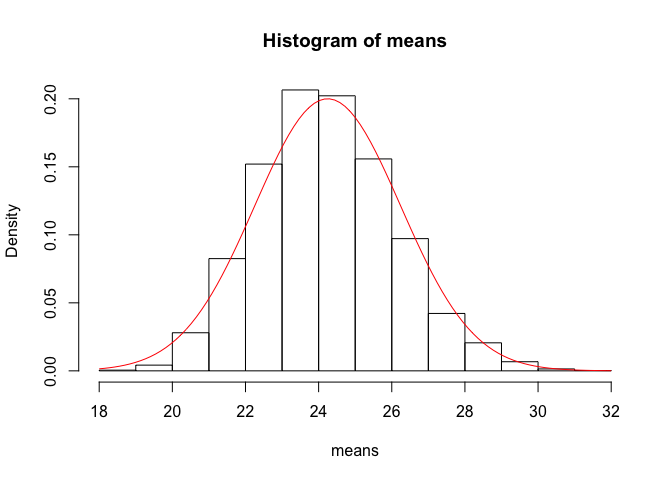

```r
SuicideAge <- subset(ForeverAlone, attempt_suicide == "Yes", age)$age
populationMean <- mean(SuicideAge) # 24.24706
populationSd <- sd(SuicideAge) # 6.307414

n <- 10
N <- 10^4

means <- numeric(N)
stdSamplesT <- numeric(N)
for (i in 1:N){
  values <- sample(SuicideAge, n)
  sampleMean <- mean(values)
  sampleSd <- sd(values)
  means[i] <- sampleMean
  stdSamplesT[i] <- (sampleMean - populationMean)/(sampleSd/sqrt(n))
}

hist(means, probability = TRUE)
curve(dnorm(x, populationMean, populationSd/sqrt(10)), add=TRUE, col="red")
```

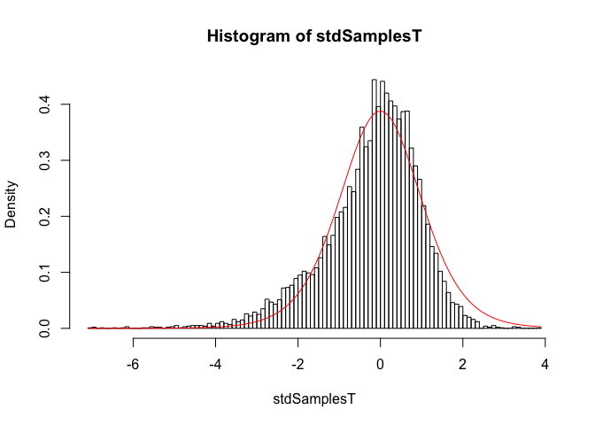

```r
hist(stdSamplesT, probability = TRUE, breaks = "FD")
curve(dt(x, n-1), add=TRUE, col="red")
```

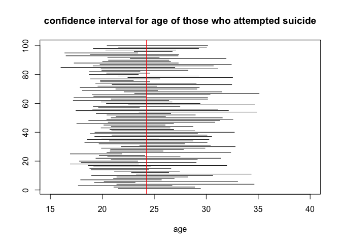

```r
#Let's see how we do with a t confidence interval
missedL <- 0; missedU <- 0
plot(x =c(15,40), y = c(1,100), type = "n", xlab = "age", ylab = "", main="confidence interval for age of those who attempted suicide") #blank plot
N <-1000
counter <- 0
for (i in 1:N) {
  x <- sample(SuicideAge, n)
  L <- mean(x) + qt(0.025, n-1) * sd(x)/sqrt(n) #usually less than the true mean
  U <- mean(x) + qt(0.975, n-1) * sd(x)/sqrt(n) #usually greater than the true mean
  if (populationMean <L) missedL <- missedL + 1 # +1 if we were wrong
  if (populationMean >U) missedU <- missedU + 1 # +1 if we were wrong
  if (L < populationMean && U > populationMean) counter <- counter + 1 #count +1 if we were correct
  if(i <= 100) segments(L, i, U, i)
}
abline (v = populationMean, col = "red") #vertical line at true mean
```

```r
(N-missedL-missedU)/N # 0.93
missedL/N # 0.006
missedU/N #0.064
```

## Age and Suicide: conclusion

The confidence interval shows that `0.93` of all intervals include the true mean. This is good because if there are campaigns for suicide prevention, they can be directed to those in their mid-twenties.

# Age, Sexuality and Suicide

Do those who are part of the LGBTQ+ community struggle more with suicide?

## Age, Sexuality, and Suicide: using ggplot

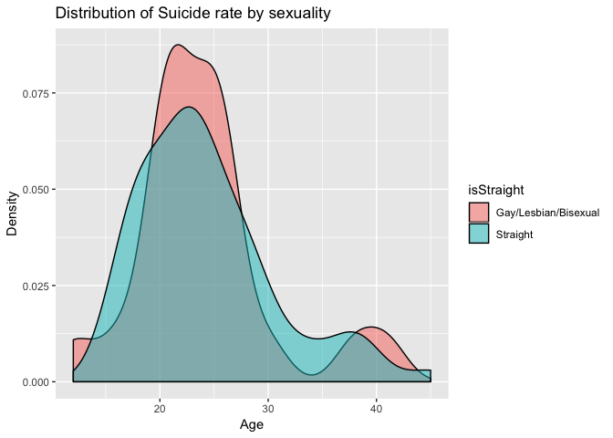

```r
ForeverAlone.SuicideSubset <- subset(ForeverAlone, attempt_suicide == "Yes")
ForeverAlone.SuicideSubset$isStraight <- ifelse(ForeverAlone.SuicideSubset$sexuallity == 'Straight', 1, 0)
ForeverAlone.SuicideSubset$isStraight <- factor(ForeverAlone.SuicideSubset$isStraight,levels=c(0,1),
   labels=c("Gay/Lesbian/Bisexual","Straight"))
qplot(age, data=ForeverAlone.SuicideSubset, geom="density", fill=isStraight, alpha=I(.5),
   main="Distribution of Suicide rate by sexuality", xlab="Age",
   ylab="Density")
```

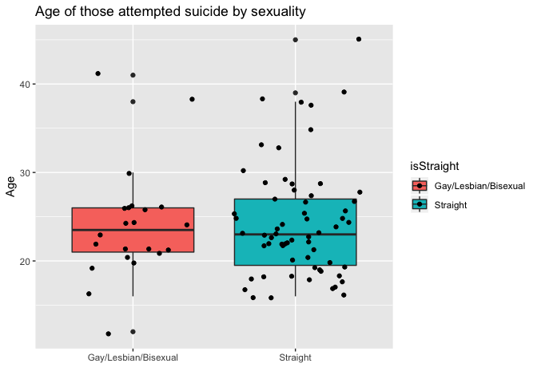

```r
qplot(isStraight, age, data=ForeverAlone.SuicideSubset, geom=c("boxplot", "jitter"),
   fill=isStraight, main="Age of those attempted suicide by sexuality",
   xlab="", ylab="Age")
```

Both are centered more in mid-20s but for those who do not identify as straight, the distribution is even more condensed in their mid-20s.

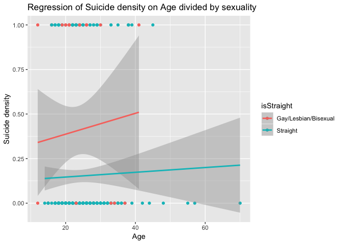

```r
ForeverAlone$hasSuicide <- ifelse(ForeverAlone$attempt_suicide == "Yes", 1, 0)
ForeverAlone$isStraight <- ifelse(ForeverAlone$sexuallity == 'Straight', 1, 0)
ForeverAlone$isStraight <- factor(ForeverAlone$isStraight,levels=c(0,1),
   labels=c("Gay/Lesbian/Bisexual","Straight"))

qplot(age, hasSuicide, data=ForeverAlone, geom=c("point", "smooth"),
   method="lm", formula=y~x, color=isStraight,
   main="Regression of Suicide density on Age divided by sexuality",
   xlab="Age", ylab="Suicide density")
```

## Age, Sexuality and Suicide : conclusion

Finding that the hotspot of people who attempted suicide is in their mid-20s and that those who are part of the LGBT has higher risk of suicide.

# Overall conclusion

Aside from this, people who attempt suicide are more likely in their 20s. Those who do not identify as straight have a higher risk of suicide.

End of document.